# Лабораторная работа 5

Модель хищник-жертва

Митрофанов Тимур Александрович

1132231842@rudn.ru

Российский университет дружбы народов

2026-04-18

# Информация

## Докладчик

- Митрофанов Тимур Александрович
- Студент
- Российский университет дружбы народов им. П. Лумумбы
- 1132231842@rudn.ru

# Вводная часть

## Актуальность

- Моделирование популяций важно для экологии и биологии
- Позволяет прогнозировать динамику взаимодействия видов
- Используется в экономике, медицине и анализе сложных систем
- Модель «хищник–жертва» — базовый пример нелинейной динамики

## Объект и предмет исследования

- Объект: популяции хищников и жертв
- Предмет: их взаимодействие во времени
- Математическая модель: система дифференциальных уравнений
- Анализ поведения системы и фазовых траекторий

## Цели и задачи

- Исследовать модель Лотки–Вольтерры
- Построить графики $x(t)$, $y(t)$
- Построить фазовый портрет $x(y)$
- Найти стационарную точку системы
- Проанализировать характер динамики

## Материалы и методы

# Математическая модель

## Модель Лотки–Вольтерры

$$\begin{cases}
\frac{dx}{dt} = ax - bxy \\
\frac{dy}{dt} = -cy + dxy
\end{cases}$$

## Стационарная точка

$$x_0 = \frac{c}{d}, \quad y_0 = \frac{a}{b}$$

- Система находится в равновесии
- При отклонении возникают колебания
- Равновесие — центр фазовых траекторий

# Ход исследования

## Постановка задачи

- Заданы начальные условия популяций
- Выполнено численное моделирование
- Построены:
  - графики $x(t)$, $y(t)$
  - фазовый портрет

## Численное моделирование

- Использован метод интегрирования ОДУ
- Рассмотрен интервал времени $t \in [0, 200]$
- Анализ поведения системы при заданных параметрах

# Результаты

## Код

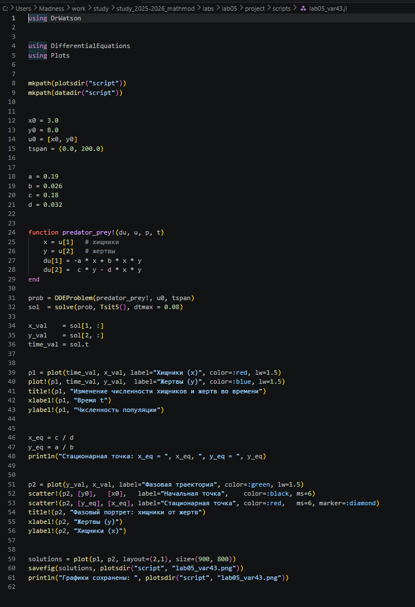

код

## Графики численности популяций

- Наблюдаются периодические колебания
- Популяции изменяются во времени циклически
- Максимумы хищников следуют за максимумами жертв
- Колебания происходят в противофазе

## Фазовый портрет

- Замкнутая траектория (предельный цикл)
- Система не стремится к равновесию
- Движение происходит вокруг стационарной точки
- Начальное состояние определяет амплитуду

## График

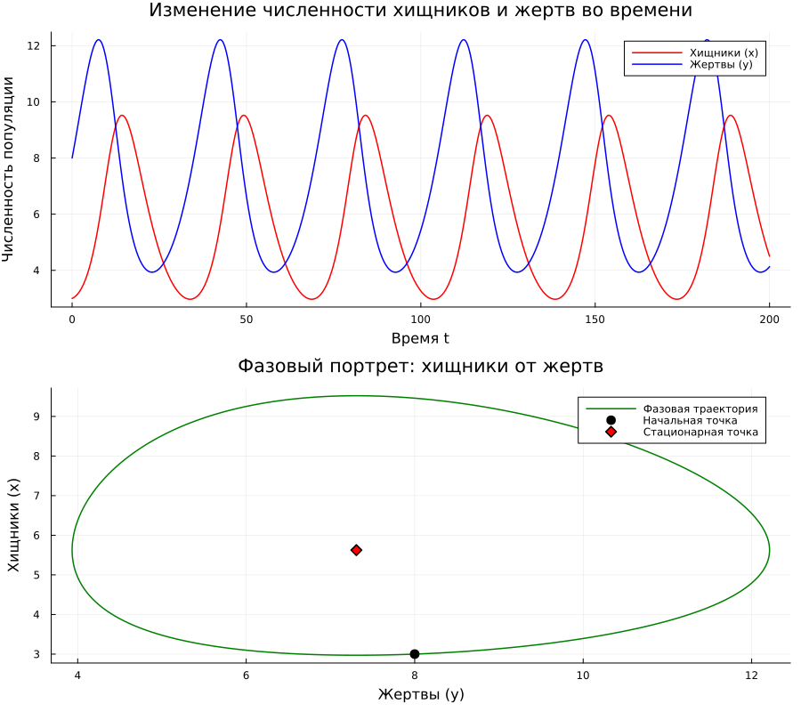

графики

## Анализ поведения системы

- Система демонстрирует устойчивые колебания
- Нет затухания или роста амплитуды
- Поведение соответствует «жёсткой» модели
- Динамика полностью определяется параметрами

# Обсуждение

## Ограничения модели

- Нет учета насыщения среды
- Нет конкуренции внутри видов
- Нет внешних факторов (болезни, климат)
- Идеализированная система

## Возможные улучшения

- Добавление логистического роста
- Учёт конкуренции
- Введение случайных факторов
- Переход к «мягкой» модели

# Итог

## Выводы

- Модель Лотки–Вольтерры описывает циклическое поведение
- Популяции колеблются в противофазе
- Фазовый портрет представляет замкнутую траекторию
- Стационарная точка не является устойчивым аттрактором

## Главное

- Простая модель даёт качественное понимание динамики
- Для реальных систем требуется усложнение модели
- Анализ фазового пространства — ключ к пониманию системы